# 第10回 発展 t-SNEとUMAP

曲がった構造の地図と、その読み方

## PCAは、まっすぐな向き

- PCAは、データのまっすぐな向きを取り出して地図にした
- 全体の散らばりを保つ。近くの点どうしの関係は後回し

## t-SNEとUMAP

- 「近くにいた点どうしは、地図でも近くに」を優先する
- 似た点どうしの群れが、島として強調される

## 3つの地図を作る

```python
import importlib.util
if importlib.util.find_spec('umap') is None:   # 無ければ入れる
    %pip install -q umap-learn
import warnings
import umap
from sklearn.manifold import TSNE

warnings.filterwarnings('ignore', message='n_jobs value')
X_s = StandardScaler().fit_transform(df[feat])
maps = {'PCA': S,
        't-SNE': TSNE(n_components=2, random_state=0).fit_transform(X_s),
        'UMAP': umap.UMAP(random_state=0).fit_transform(X_s)}
```

## PCAの地図

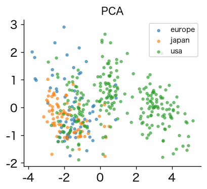

- アメリカ車が右、日本・ヨーロッパ車が左に、なめらかに広がる

## t-SNEとUMAPの地図

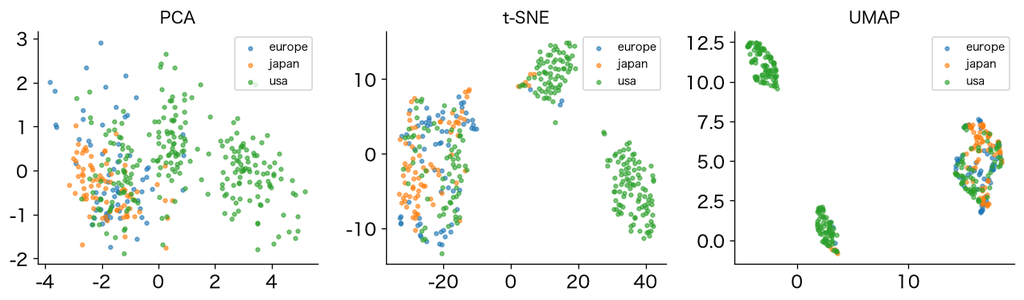

- 点が、大きな3つの島に分かれる

## 島は、気筒数ごと

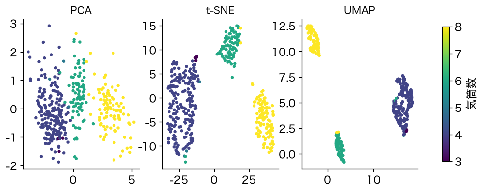

- 気筒数は、ほぼ4・6・8のとびとびの値。その列がつくる群れが、島になる

## PCAにも、同じ帯がある

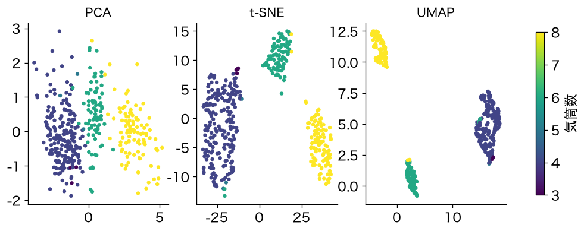

- PCAの地図も、気筒数ごとの帯に分かれている。島は、それを強調したもの

## 軸には、意味がない

- t-SNEとUMAPには、負荷量がない
- 「右ほど大きい車」とは、読めない

## 注意①：種で、形が変わる

```python
# 注意①：乱数の種を変えると、地図の形が変わる
# init='random' は、はじめの点の置き方をでたらめにする指定
fig, axes = plt.subplots(1, 3, figsize=(13, 4.2))
for ax, seed in zip(axes, [0, 1, 2]):
    tsne = TSNE(n_components=2, init='random', random_state=seed)
    Z = tsne.fit_transform(X_s)
    sc = ax.scatter(Z[:, 0], Z[:, 1], s=10, c=df['cylinders'],
                    cmap='viridis')
    ax.set_title(f't-SNE（種 {seed}）')
fig.colorbar(sc, ax=axes, label='気筒数')     # 色と気筒数の対応
plt.show()
```

## 3つの種

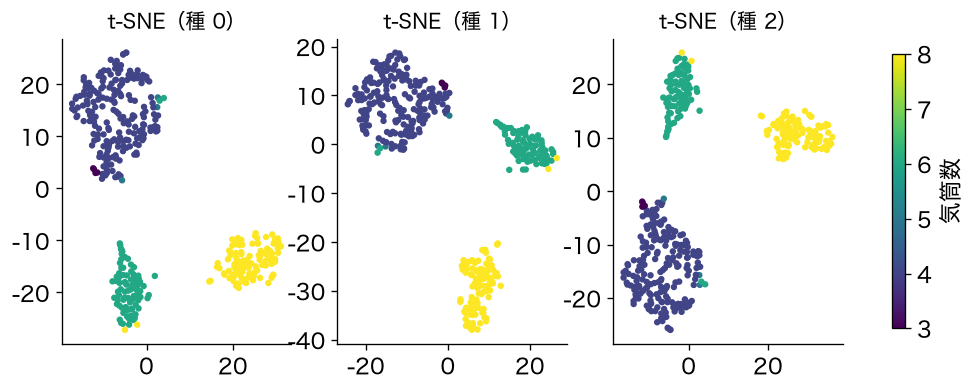

- 島の位置や向きが、まるで変わる

## 島どうしの位置は、読めない

- 島の中の顔ぶれは、だいたい同じ
- でも、「島Aと島Bが近い」とは読めない

## 注意②：遠い距離は、保たれない

```python
d_orig = pdist(X_s)                        # 6つの性能での、車どうしの距離
for name, Z in maps.items():
    r = np.corrcoef(d_orig, pdist(Z))[0, 1]
    print(f'{name:6s}: 元の距離との相関 {r:.2f}')
```

```
PCA   : 元の距離との相関 0.99
t-SNE : 元の距離との相関 0.91
UMAP  : 元の距離との相関 0.83
```

## 近くを守り、遠くを犠牲に

- PCAが、元の距離をいちばん保つ
- t-SNEとUMAPは、近くの関係を守るかわりに、遠い距離を犠牲にする

## 使い分け

- 「似たものの島があるか」を眺める → t-SNE・UMAP
- 地図の距離や軸を読む → PCA

## 試すなら

- `umap.UMAP(n_neighbors=5)`や`n_neighbors=50`にする
- 近くとみなす点の数で、島の分かれ方はどう変わるか？